# Chapter 8 Solutions Exercises

### 8.3.3 Exercise 3: Correlation

a. Make a scatter plot where you plot `Sepal.length` on the x-axis and `Sepal.width` on the y-axis. Make the plot for the species `virginica`

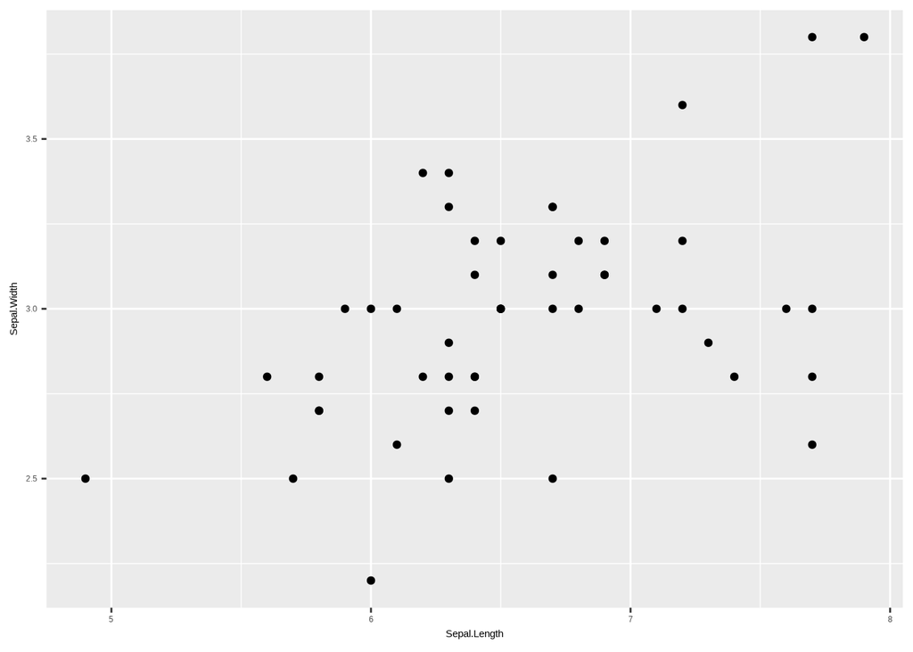

```r
#Preparing the data
d1 <- iris %>%
  filter(Species == "virginica")

#Making the plot
ggplot(d1, aes(x = Sepal.Length, y = Sepal.Width)) +
  geom_point()
```

b. Now I want you to add the species `versicolor` to the plot. The dots of this species should have a different color AND a different form.

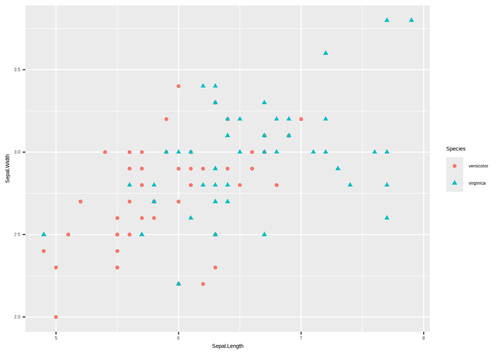

```r
#Preparing the Data
d1 <- iris %>%
  filter(Species %in% c("virginica", "versicolor"))

#Making the Plot
ggplot(d1, aes(x = Sepal.Length, y = Sepal.Width,
               shape = Species, color = Species)) +
  geom_point()
```

c. Make a nice plot! Add a theme, labels, and a nice title, increase the size of the forms and make play around with the colors.

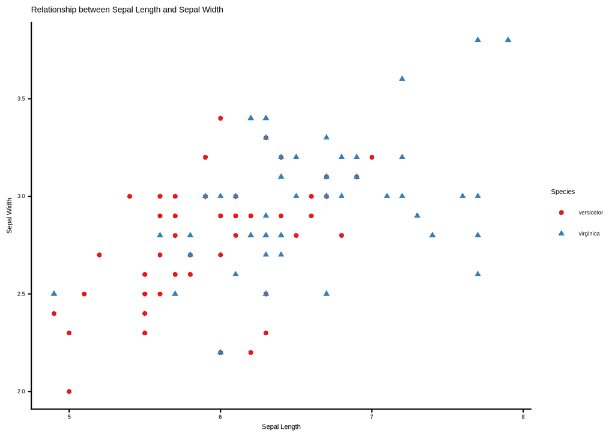

```r
#Making the Plot
ggplot(d1, aes(x = Sepal.Length, y = Sepal.Width,
               shape = Species, color = Species)) +
  geom_point() +
  labs(
    title = "Relationship between Sepal Length and Sepal Width",
    x = "Sepal Length",
    y = "Sepal Width"
  ) +
  scale_color_brewer(palette = "Set1") +
  theme_classic()
```

## 8.4 Chapter 4: Exploratory Data Analysis

### 8.4.1 Exercise 1: Standard Descriptive Statistics

In this exercise we will work with the built-in `iris` package in R:

a. Calculate the mode, mean and the median for the `iris$Sepal.Length` variable

```r
mean(iris$Sepal.Length) #Calculating the mean
```

```
## [1] 5.843333
```

```r
median(iris$Sepal.Length) # Calculating the median
```

```
## [1] 5.8
```

```r
#Calculating the mode
uniq_vals <- unique(iris$Sepal.Length)
freqs <- tabulate(iris$Sepal.Length)
uniq_vals[which.max(freqs)]
```

```
## [1] 5
```

```r
# You could also define a function for the mode

#mode <- function (x) {
#  uniq_vals <- unique(x, na.rm = TRUE)
#  freqs <- tabulate(match(x, uniq_vals))
#  uniq_vals[which.max(freqs)]
#}
#mode(iris$Sepal.Length)
```

b. Calculate the interquartile range, variance and the standard deviation for iris$Sepal.Length

```r
IQR(iris$Sepal.Length)
```

```
## [1] 1.3
```

```r
var(iris$Sepal.Length) #Variance
```

```
## [1] 0.6856935
```

```r
sd(iris$Sepal.Length) #Standard deviatio
```

```
## [1] 0.8280661
```

```r
#Or we take just the squareroot of the variance to get the sd
#var(iris$Sepal.Length) %>%
#  sqrt()
```

c. Calculate all five measures at once by using a function that does so (Choose by yourself, which one you want to use)

```r
psych::describe(iris$Sepal.Length) #psych package
```

```
##    vars   n mean   sd median trimmed  mad min max range skew
## X1    1 150 5.84 0.83    5.8    5.81 1.04 4.3 7.9   3.6 0.31
##    kurtosis   se
## X1    -0.61 0.07
```

```r
skimr::skim(iris$Sepal.Length) #skim package
```

| Name | iris$Sepal.Length |
| --- | --- |
| Number of rows | 150 |
| Number of columns | 1 |
| _______________________ |  |
| Column type frequency: |  |
| numeric | 1 |
| ________________________ |  |
| Group variables | None |

**Variable type: numeric**

| skim_variable | n_missing | complete_rate | mean | sd | p0 | p25 | p50 | p75 | p100 | hist |
| --- | --- | --- | --- | --- | --- | --- | --- | --- | --- | --- |
| data | 0 | 1 | 5.84 | 0.83 | 4.3 | 5.1 | 5.8 | 6.4 | 7.9 | ▆▇▇▅▂ |

```r
summarytools::descr(iris$Sepal.Length) #summarytools package
```

```
## Descriptive Statistics
## iris$Sepal.Length
## N: 150
##
##                     Sepal.Length
## ----------------- --------------
##              Mean           5.84
##           Std.Dev           0.83
##               Min           4.30
##                Q1           5.10
##            Median           5.80
##                Q3           6.40
##               Max           7.90
##               MAD           1.04
##               IQR           1.30
##                CV           0.14
##          Skewness           0.31
##       SE.Skewness           0.20
##          Kurtosis          -0.61
##           N.Valid         150.00
##                 N         150.00
##         Pct.Valid         100.00
```

### 8.4.2 Exercise 2: Contingency Tables and Correlations

a. Make a Contingency Table for `esoph$agegp` and `esoph$alcgp`

```r
table(esoph$agegp, esoph$alcgp) #with base R
```

```
##
##         0-39g/day 40-79 80-119 120+
##   25-34         4     4      3    4
##   35-44         4     4      4    3
##   45-54         4     4      4    4
##   55-64         4     4      4    4
##   65-74         4     3      4    4
##   75+           3     4      2    2
```

```r
summarytools::ctable(esoph$agegp, esoph$alcgp) #with summarytools
```

```
## Cross-Tabulation, Row Proportions
## agegp * alcgp
## Data Frame: esoph
##
## ------- ------- ------------ ------------ ------------ ------------ -------------
##           alcgp    0-39g/day        40-79       80-119         120+         Total
##   agegp
##   25-34            4 (26.7%)    4 (26.7%)    3 (20.0%)    4 (26.7%)   15 (100.0%)
##   35-44            4 (26.7%)    4 (26.7%)    4 (26.7%)    3 (20.0%)   15 (100.0%)
##   45-54            4 (25.0%)    4 (25.0%)    4 (25.0%)    4 (25.0%)   16 (100.0%)
##   55-64            4 (25.0%)    4 (25.0%)    4 (25.0%)    4 (25.0%)   16 (100.0%)
##   65-74            4 (26.7%)    3 (20.0%)    4 (26.7%)    4 (26.7%)   15 (100.0%)
##     75+            3 (27.3%)    4 (36.4%)    2 (18.2%)    2 (18.2%)   11 (100.0%)
##   Total           23 (26.1%)   23 (26.1%)   21 (23.9%)   21 (23.9%)   88 (100.0%)
## ------- ------- ------------ ------------ ------------ ------------ -------------
```

```r
gtsummary::tbl_cross(data = esoph,
                     row = agegp,
                     col = alcgp) #with gtsummary
```

|  | alcgp 0-39g/day | alcgp 40-79 | alcgp 80-119 | alcgp 120+ | Total |  |
| --- | --- | --- | --- | --- | --- | --- |
| agegp |  |  |  |  |  |  |
| 25-34 | 4 | 4 | 3 | 4 | 15 |  |
| 35-44 | 4 | 4 | 4 | 3 | 15 |  |
| 45-54 | 4 | 4 | 4 | 4 | 16 |  |
| 55-64 | 4 | 4 | 4 | 4 | 16 |  |
| 65-74 | 4 | 3 | 4 | 4 | 15 |  |
| 75+ | 3 | 4 | 2 | 2 | 11 |  |
| Total | 23 | 23 | 21 | 21 | 88 |  |

b. Cut down the iris dataset to Sepal.Length, Sepal.Width, Petal.Length and Petal.Width and save it in an object called iris_numeric.

```r
iris_numeric <- iris %>%
  select(Sepal.Length, Sepal.Width, Petal.Length, Petal.Width)
```

c. Make a correlation matrix with iris_numeric

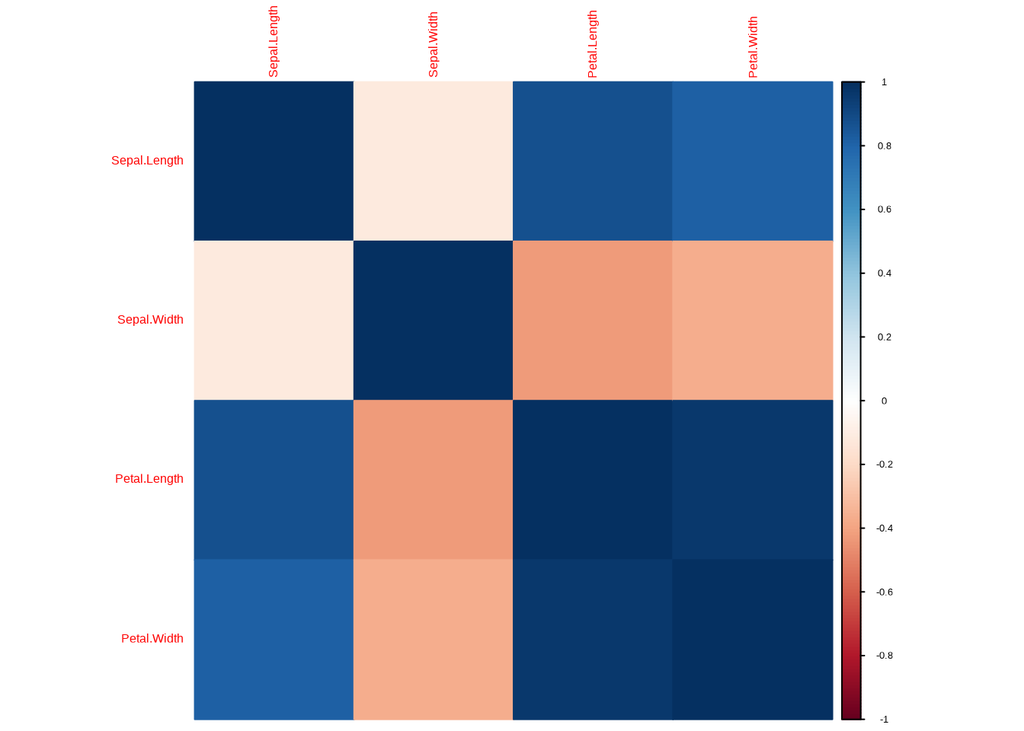

```r
#With corrplot package
cor_iris <- cor(iris_numeric)
corrplot::corrplot(cor_iris, method = "color")
```

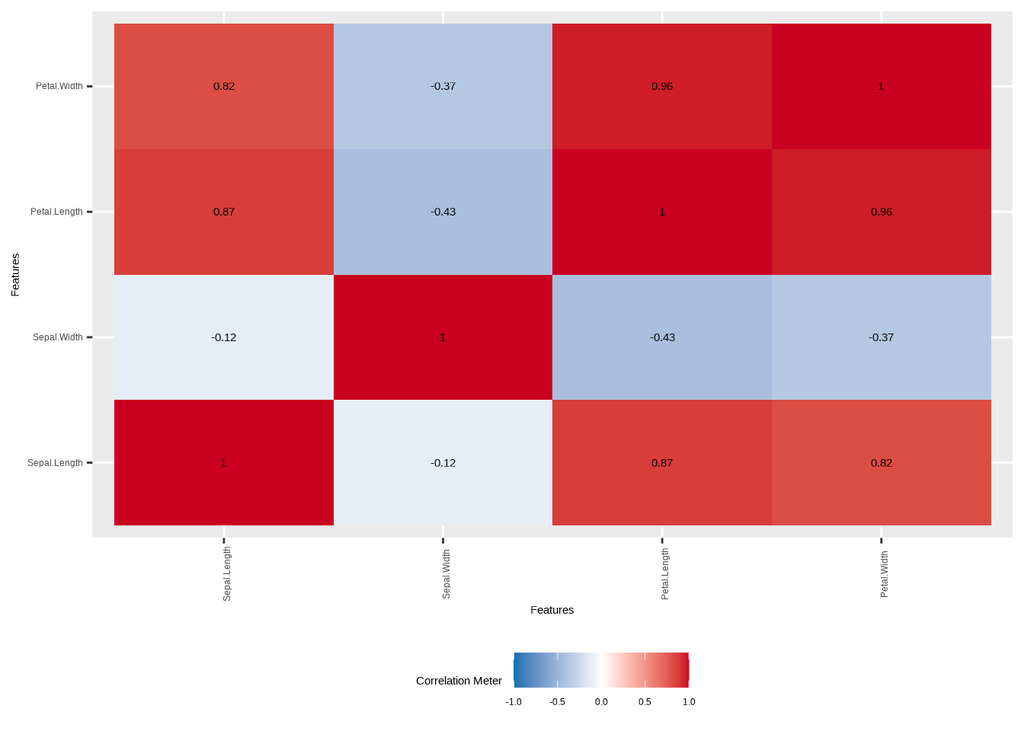

```r
#With DataExplorer
DataExplorer::plot_correlation(iris_numeric)
```

d. Make the correlation matrix pretty

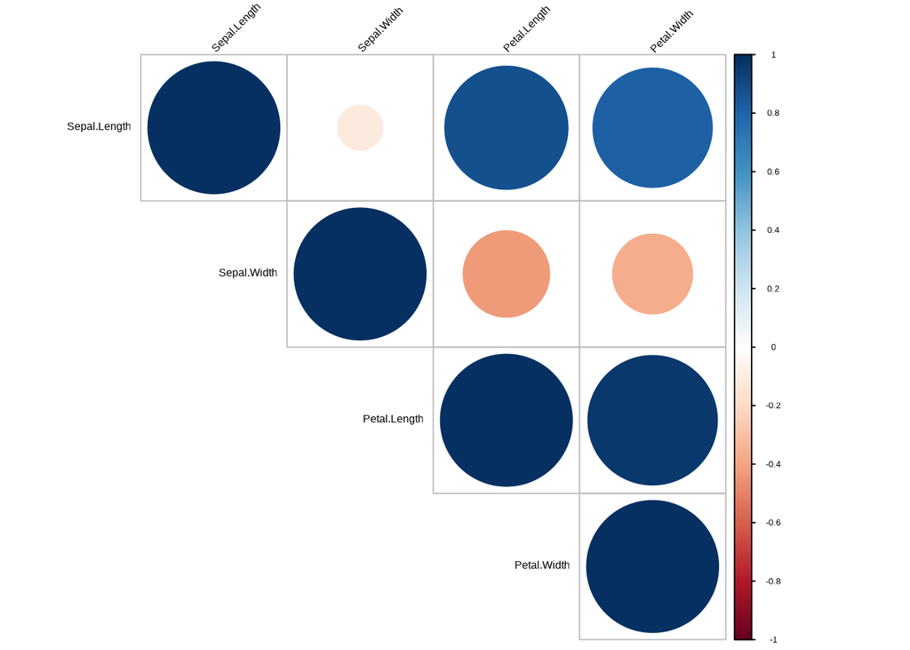

```r
# With Corrplot
corrplot::corrplot(cor_iris, method = "circle", type = "upper",
         tl.col = "black", tl.srt = 45)
```

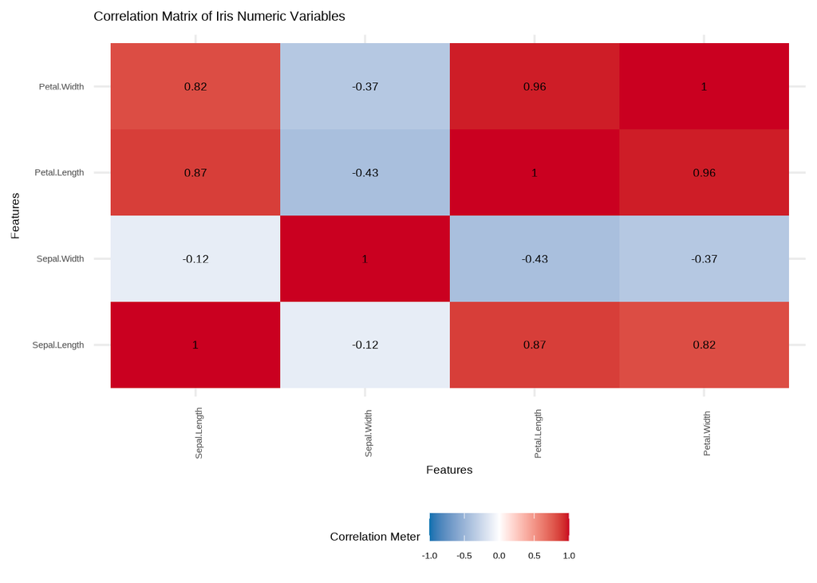

```r
# With DataExplorer
DataExplorer::plot_correlation(
  iris_numeric,
  ggtheme = theme_minimal(base_size = 14),
  title = "Correlation Matrix of Iris Numeric Variables"
)
```

### 8.4.3 Exercise 3: Working with packages

a. Use a function to get an overview of the dataset mtcars

```r
skimr::skim(mtcars)
```

| Name | mtcars |
| --- | --- |
| Number of rows | 32 |
| Number of columns | 11 |
| _______________________ |  |
| Column type frequency: |  |
| numeric | 11 |
| ________________________ |  |
| Group variables | None |

**Variable type: numeric**

| skim_variable | n_missing | complete_rate | mean | sd | p0 | p25 | p50 | p75 | p100 | hist |
| --- | --- | --- | --- | --- | --- | --- | --- | --- | --- | --- |
| mpg | 0 | 1 | 20.09 | 6.03 | 10.40 | 15.43 | 19.20 | 22.80 | 33.90 | ▃▇▅▁▂ |
| cyl | 0 | 1 | 6.19 | 1.79 | 4.00 | 4.00 | 6.00 | 8.00 | 8.00 | ▆▁▃▁▇ |
| disp | 0 | 1 | 230.72 | 123.94 | 71.10 | 120.83 | 196.30 | 326.00 | 472.00 | ▇▃▃▃▂ |
| hp | 0 | 1 | 146.69 | 68.56 | 52.00 | 96.50 | 123.00 | 180.00 | 335.00 | ▇▇▆▃▁ |
| drat | 0 | 1 | 3.60 | 0.53 | 2.76 | 3.08 | 3.70 | 3.92 | 4.93 | ▇▃▇▅▁ |
| wt | 0 | 1 | 3.22 | 0.98 | 1.51 | 2.58 | 3.33 | 3.61 | 5.42 | ▃▃▇▁▂ |
| qsec | 0 | 1 | 17.85 | 1.79 | 14.50 | 16.89 | 17.71 | 18.90 | 22.90 | ▃▇▇▂▁ |
| vs | 0 | 1 | 0.44 | 0.50 | 0.00 | 0.00 | 0.00 | 1.00 | 1.00 | ▇▁▁▁▆ |
| am | 0 | 1 | 0.41 | 0.50 | 0.00 | 0.00 | 0.00 | 1.00 | 1.00 | ▇▁▁▁▆ |
| gear | 0 | 1 | 3.69 | 0.74 | 3.00 | 3.00 | 4.00 | 4.00 | 5.00 | ▇▁▆▁▂ |
| carb | 0 | 1 | 2.81 | 1.62 | 1.00 | 2.00 | 2.00 | 4.00 | 8.00 | ▇▂▅▁▁ |

```r
summarytools::dfSummary(mtcars)
```

```
## Data Frame Summary
## mtcars
## Dimensions: 32 x 11
## Duplicates: 0
##
## ----------------------------------------------------------------------------------------------------------
## No   Variable    Stats / Values              Freqs (% of Valid)   Graph               Valid      Missing
## ---- ----------- --------------------------- -------------------- ------------------- ---------- ---------
## 1    mpg         Mean (sd) : 20.1 (6)        25 distinct values     :                 32         0
##      [numeric]   min < med < max:                                   : .               (100.0%)   (0.0%)
##                  10.4 < 19.2 < 33.9                               . : :
##                  IQR (CV) : 7.4 (0.3)                             : : :   .
##                                                                   : : : : :
##
## 2    cyl         Mean (sd) : 6.2 (1.8)       4 : 11 (34.4%)       IIIIII              32         0
##      [numeric]   min < med < max:            6 :  7 (21.9%)       IIII                (100.0%)   (0.0%)
##                  4 < 6 < 8                   8 : 14 (43.8%)       IIIIIIII
##                  IQR (CV) : 4 (0.3)
##
## 3    disp        Mean (sd) : 230.7 (123.9)   27 distinct values     :                 32         0
##      [numeric]   min < med < max:                                 . :                 (100.0%)   (0.0%)
##                  71.1 < 196.3 < 472                               : : :   : : :
##                  IQR (CV) : 205.2 (0.5)                           : : :   : : :   .
##                                                                   : : : . : : : . :
##
## 4    hp          Mean (sd) : 146.7 (68.6)    22 distinct values   . :                 32         0
##      [numeric]   min < med < max:                                 : :                 (100.0%)   (0.0%)
##                  52 < 123 < 335                                   : : : .
##                  IQR (CV) : 83.5 (0.5)                            : : : :
##                                                                   : : : : . .
##
## 5    drat        Mean (sd) : 3.6 (0.5)       22 distinct values       :               32         0
##      [numeric]   min < med < max:                                   : :               (100.0%)   (0.0%)
##                  2.8 < 3.7 < 4.9                                    : : .
##                  IQR (CV) : 0.8 (0.1)                             . : : :
##                                                                   : : : : .
##
## 6    wt          Mean (sd) : 3.2 (1)         29 distinct values         :             32         0
##      [numeric]   min < med < max:                                       : :           (100.0%)   (0.0%)
##                  1.5 < 3.3 < 5.4                                        : :
```

[output cut: 14 more lines]

```
##      [numeric]   Mean : 0.4                  1 : 13 (40.6%)       IIIIIIII            (100.0%)   (0.0%)
##                  Max  : 1
##
## 10   gear        Mean (sd) : 3.7 (0.7)       3 : 15 (46.9%)       IIIIIIIII           32         0
##      [numeric]   min < med < max:            4 : 12 (37.5%)       IIIIIII             (100.0%)   (0.0%)
##                  3 < 4 < 5                   5 :  5 (15.6%)       III
##                  IQR (CV) : 1 (0.2)
##
## 11   carb        Mean (sd) : 2.8 (1.6)       1 :  7 (21.9%)       IIII                32         0
##      [numeric]   min < med < max:            2 : 10 (31.2%)       IIIIII              (100.0%)   (0.0%)
##                  1 < 2 < 8                   3 :  3 ( 9.4%)       I
##                  IQR (CV) : 2 (0.6)          4 : 10 (31.2%)       IIIIII
##                                              6 :  1 ( 3.1%)
##                                              8 :  1 ( 3.1%)
## ----------------------------------------------------------------------------------------------------------
```

```r
gtsummary::tbl_summary(mtcars)
```

| **Characteristic** | **N = 32**<sup>1</sup> |
| --- | --- |
| mpg | 19.2 (15.4, 22.8) |
| cyl |  |
| 4 | 11 (34%) |
| 6 | 7 (22%) |
| 8 | 14 (44%) |
| disp | 196 (121, 334) |
| hp | 123 (96, 180) |
| drat | 3.70 (3.08, 3.92) |
| wt | 3.33 (2.54, 3.65) |
| qsec | 17.71 (16.89, 18.90) |
| vs | 14 (44%) |
| am | 13 (41%) |
| gear |  |
| 3 | 15 (47%) |
| 4 | 12 (38%) |
| 5 | 5 (16%) |
| carb |  |
| 1 | 7 (22%) |
| 2 | 10 (31%) |
| 3 | 3 (9.4%) |
| 4 | 10 (31%) |
| 6 | 1 (3.1%) |
| 8 | 1 (3.1%) |

<sup>1</sup> Median (Q1, Q3); n (%)

b. Have a look at the structure of the missing values in mtcars

```r
# With a table
naniar::miss_var_summary(mtcars)
```

```
## # A tibble: 11 × 3
##    variable n_miss pct_miss
##    <chr>     <int>    <num>
##  1 mpg           0        0
##  2 cyl           0        0
##  3 disp          0        0
##  4 hp            0        0
##  5 drat          0        0
##  6 wt            0        0
##  7 qsec          0        0
##  8 vs            0        0
##  9 am            0        0
## 10 gear          0        0
## 11 carb          0        0
```

```r
DataExplorer::introduce(mtcars)
```

```
##   rows columns discrete_columns continuous_columns
## 1   32      11                0                 11
##   all_missing_columns total_missing_values complete_rows
## 1                   0                    0            32
##   total_observations memory_usage
## 1                352         5928
```

```r
SmartEDA::ExpData(mtcars, type = 1)
```

```
##                                           Descriptions
## 1                                   Sample size (nrow)
## 2                              No. of variables (ncol)
## 3                    No. of numeric/interger variables
## 4                              No. of factor variables
## 5                                No. of text variables
## 6                             No. of logical variables
## 7                          No. of identifier variables
## 8                                No. of date variables
## 9             No. of zero variance variables (uniform)
## 10               %. of variables having complete cases
## 11   %. of variables having >0% and <50% missing cases
## 12 %. of variables having >=50% and <90% missing cases
## 13          %. of variables having >=90% missing cases
##        Value
## 1         32
## 2         11
## 3         11
## 4          0
## 5          0
## 6          0
## 7          0
## 8          0
## 9          0
## 10 100% (11)
## 11    0% (0)
## 12    0% (0)
## 13    0% (0)
```

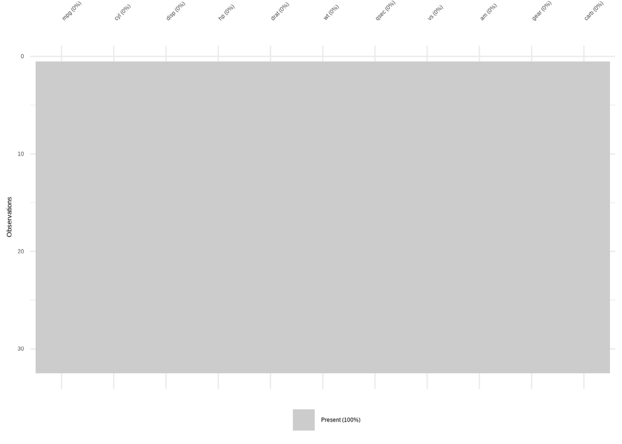

```r
# Graphically
naniar::vis_miss(mtcars)
```

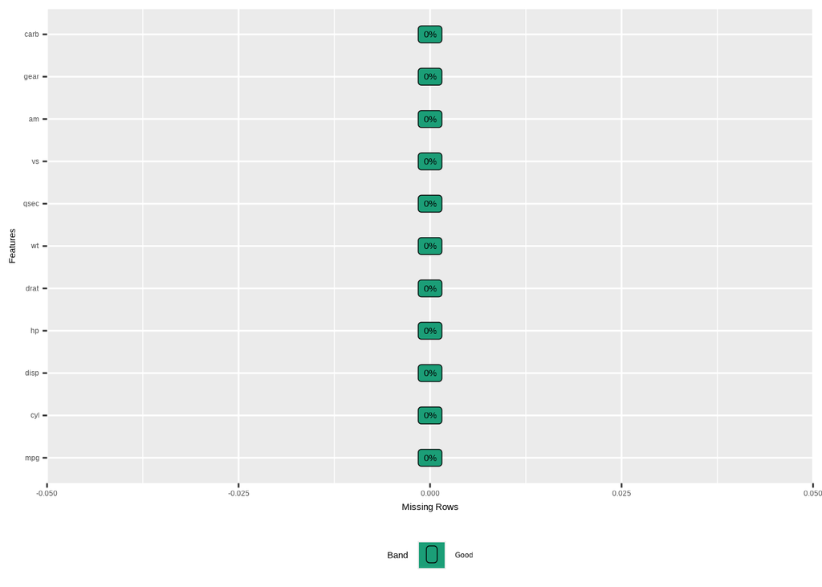

```r
DataExplorer::plot_missing(mtcars)
```

c. Make an automized EDA report for mtcars!

`dlookr::describe(mtcars)`

`DataExplorer::create_report(mtcars)`

## 8.5 Chapter 5: Data Analysis

To understand linear regression, we do not have to load any complicated data. Let us assume, you are a market analyst and your customer is the production company of a series called “Breaking Thrones”. The production company wants to know how the viewers of the series judge the final episode. You conduct a survey and ask people on how satisfied they were with the season final and some social demographics. Here is your codebook:

| Variable | Description |
| --- | --- |
| id | The id of the respondent |
| satisfaction | The answer to the question “How satisfied were you with the final episode of Breaking Throne?”, where 0 is completely dissatisfied and 10 completely satisfied |
| age | The age of the respondent |
| female | The Gender of the respondent, where 0 = Male, 1 = Female |

Let us generate the data:

```r
#setting seed for reproduciability
set.seed(123)

#Generating the data
final_BT <- data.frame(
  id = c(1:10),
  satisfaction = round(rnorm(10, mean = 6, sd = 2.5)),
  age = round(rnorm(10, mean = 25, sd = 5)),
  female = rbinom(10, 1, 0.5)
  )

#Print the Data Frame
print(final_BT)
```

```
##    id satisfaction age female
## 1   1            5  31      0
## 2   2            5  27      0
## 3   3           10  27      0
## 4   4            6  26      0
## 5   5            6  22      0
## 6   6           10  34      0
## 7   7            7  27      0
## 8   8            3  15      0
## 9   9            4  29      0
## 10 10            5  23      1
```

### 8.5.1 Exercise 1: Linear Regression with two variables

You want to know if age has an impact on the satisfaction with the last episode. You want to conduct a linear regression.

a. Calculate $\beta_0$ and $\beta_1$ by hand

```r
#Calculating Covariance
cov <- sum((final_BT$age - mean(final_BT$age)) * (final_BT$satisfaction - mean(final_BT$satisfaction)))

#Calculating Variance
var <- (sum((final_BT$age - mean(final_BT$age))^2))

#Calculating beta_1
beta_1 <- cov/var

#printing beta_1
print(beta_1)
```

```
## [1] 0.2466586
```

```r
#calculating beta 1
beta_0 <- mean(final_BT$satisfaction) - (beta_1 * mean(final_BT$age))

#Print both
print(beta_0)
```

```
## [1] -0.3377886
```

```r
print(beta_1)
```

```
## [1] 0.2466586
```

b. Calculate $\beta_0$ and $\beta_1$ automatically with R

```r
#Calculating it automatically
summary(m1 <- lm(satisfaction ~ age,
                 data = final_BT))
```

```
##
## Call:
## lm(formula = satisfaction ~ age, data = final_BT)
##
## Residuals:
##     Min      1Q  Median      3Q     Max
## -2.8153 -1.0820 -0.2053  0.8530  3.6780
##
## Coefficients:
##             Estimate Std. Error t value Pr(>|t|)
## (Intercept)  -0.3378     3.4796  -0.097   0.9251
## age           0.2467     0.1310   1.883   0.0964 .
## ---
## Signif. codes:  0 '***' 0.001 '**' 0.01 '*' 0.05 '.' 0.1 ' ' 1
##
## Residual standard error: 2.058 on 8 degrees of freedom
## Multiple R-squared:  0.3072, Adjusted R-squared:  0.2206
## F-statistic: 3.547 on 1 and 8 DF,  p-value: 0.0964
```

c. Interpret all quantities of your result: Standard Error, t-statistic, p-value, confidence intervals and the $R^2$.

d. Check for influential outliers

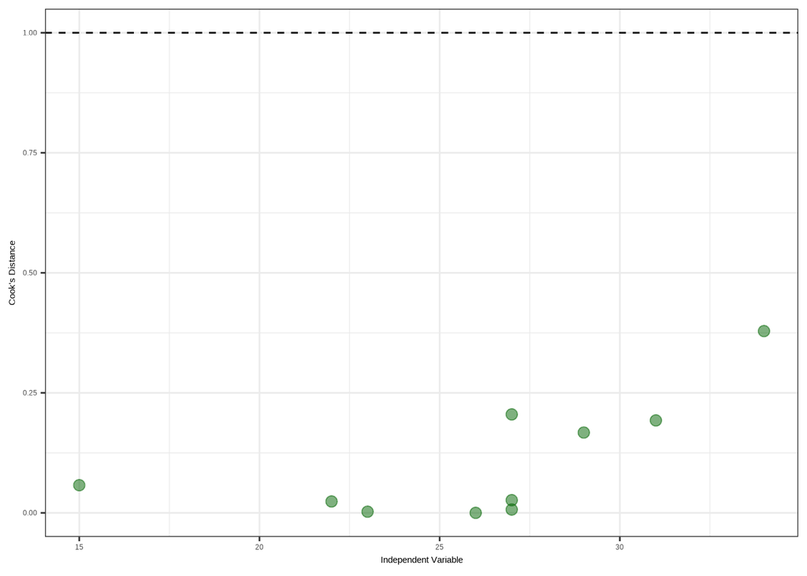

```r
#Cooks Distance can be calculated with a built-in function
final_BT$cooks_distance <- cooks.distance(m1)

#Plotting it
ggplot(final_BT, aes(x = age, y = cooks_distance)) +
  geom_point(colour = "darkgreen", size = 3, alpha = 0.5) +
  labs(y = "Cook's Distance", x = "Independent Variable") +
  geom_hline(yintercept = 1, linetype = "dashed") +
  theme_bw()
```

### 8.5.2 Exercise 2: Multivariate Regression

a. Add the variable `female` to your regression

```r
summary(m1 <- lm(satisfaction ~ age + female,
                 data = final_BT))
```

```
##
## Call:
## lm(formula = satisfaction ~ age + female, data = final_BT)
##
## Residuals:
##     Min      1Q  Median      3Q     Max
## -2.8401 -1.1312 -0.0574  0.8001  3.6435
##
## Coefficients:
##             Estimate Std. Error t value Pr(>|t|)
## (Intercept)  -0.1712     3.8481  -0.044    0.966
## age           0.2418     0.1429   1.692    0.134
## female       -0.3895     2.3662  -0.165    0.874
##
## Residual standard error: 2.196 on 7 degrees of freedom
## Multiple R-squared:  0.3099, Adjusted R-squared:  0.1127
## F-statistic: 1.571 on 2 and 7 DF,  p-value: 0.2731
```

b. Interpret the Output. What has changed? What stood the same?

c. Make an interaction effect between age and female and interpret it!

```r
summary(m2 <- lm(satisfaction ~ age + female + age:female,
                 data = final_BT))
```

```
##
## Call:
## lm(formula = satisfaction ~ age + female + age:female, data = final_BT)
##
## Residuals:
##     Min      1Q  Median      3Q     Max
## -2.8401 -1.1312 -0.0574  0.8001  3.6435
##
## Coefficients: (1 not defined because of singularities)
##             Estimate Std. Error t value Pr(>|t|)
## (Intercept)  -0.1712     3.8481  -0.044    0.966
## age           0.2418     0.1429   1.692    0.134
## female       -0.3895     2.3662  -0.165    0.874
## age:female        NA         NA      NA       NA
##
## Residual standard error: 2.196 on 7 degrees of freedom
## Multiple R-squared:  0.3099, Adjusted R-squared:  0.1127
## F-statistic: 1.571 on 2 and 7 DF,  p-value: 0.2731
```

d. Plot the interaction and make the plot nice

[output not shown]

[figure not shown]

```r
plot_model(m2, type = "int") +
  scale_x_continuous(breaks = seq(0,60, 1)) +
  labs(title = "Relationship of Age and Gender on Satisfaction with BT.",
       x = "Age",
       y = "Satisfaction") +
  scale_color_manual(
    values = c("red", "blue"),
    labels = c("Female", "Male")
  ) +
  theme_sjplot() +
  theme(legend.position = "bottom",
        legend.title = element_blank())
```

## 8.6 Chapter 6: Loops and Functions Exercises

### 8.6.1 Exercise 1: Writing a loop

Write a `for` loop that prints the square of each number from 1 to 10

```r
#Assigning an object for a better workflow
number <- 10

#correct loop
for (i in 1:number) {
  print(i^2)
}
```

```
## [1] 1
## [1] 4
## [1] 9
## [1] 16
## [1] 25
## [1] 36
## [1] 49
## [1] 64
## [1] 81
## [1] 100
```

### 8.6.2 Exercise 2: Writing a function

Write a function that takes the input x and squares it:

```r
#Defining a function for squaring
sq <- function (x) {
  x_squared <- x^2
  return(x_squared)
}

#Defining a vector containing a vector from 1 to 10
numbers <- c(1:10)

#Applying the number
sq(numbers)
```

[output not shown]

### 8.6.3 Exercise 3: The midnight Formula

This is the midnight formula separated in two equations:

$x_{1,2} = \frac{-b \pm \sqrt{b^2 - 4ac}}{2a}$

**Hint**: You need two split up the formula into two equations with two outputs.

```r
mnf <- function(a, b, c) {

  x_1 <- (-b + sqrt(b^2 - 4*a*c))/(2*a)

  print(x_1)

  x_2 <- (-b - sqrt(b^2 - 4*a*c))/(2*a)

  print(x_2)

}

#Test it with these numbers (other numbers might throw an error if the number under the square root is negative)
mnf(2, 20, 8)
```

[output not shown]